```r
source("../R/01_00_load_data.R")
```

## (a) Bootstrap estimate of SE

Use the bootstrap to estimate the standard error of $\hat\theta = \mu_A - \mu_B$, where $\mu_A$ and $\mu_B$ are sample means of counts for methods A and B, respectively. Use $B = 2000$ bootstrap samples. Assume the replicates are **unpaired**.

Notes: * Let $A=X$ and $Y=B$. I am changing the labeling so as not to confuse with the number of bootstrap samples, $B$. * sampling is unpaired * Poisson distribution is assumed. Hence, this is parametric bootstrap. Recall:

$$\begin{equation}
\begin{aligned}
\mathcal P(X = x \mid \lambda) = \frac{e^{-\lambda} \lambda^x}{x!};
\quad x = 0, 1, \dots; \quad 0 \leq \lambda < \infty
\end{aligned}
\end{equation}$$

- According to this reference. A sufficient statistic for the parameter of the Poisson distribution, $\lambda$ is $\sum_{i = 1}^n x_i$. Since it is sufficient to know the average if we know the sum (given the sample), then we can also take the mean as another sufficient statistic.

**Step 1**: Calculate a sufficient statistic for $\lambda_X$ (method A) and $\lambda_Y$ (method B).

$$\begin{equation}
\begin{aligned}
\hat \lambda_X = \frac {\sum_{i = 1}^n x_i}{n} \\
\hat \lambda_Y = \frac {\sum_{i = 1}^n y_i}{n}
\end{aligned}
\end{equation}$$

**Step 2**: Let $B$ be the number of bootstrap samples taken. With $n = $8 and for each method, sample from the plug-in distribution.

$$\begin{equation}
\begin{aligned}
B^*_{Y,1} &= \left\{y_{1,1}^*, \dots, y_{1,8}^*\right\}
\overset{iid}\sim \mathcal P\left(\hat \lambda_Y\right)\\
B^*_{Y,2} &= \left\{y_{2,1}^*, \dots, y_{2,8}^*\right\}
\overset{iid}\sim \mathcal P\left(\hat \lambda_Y\right)\\
\vdots &= \vdots \\
B^*_{Y,2000} &= \left\{y_{2000,1}^*, \dots, y_{2000,8}^*\right\}
\overset{iid}\sim \mathcal P\left(\hat \lambda_Y\right)\\
\end{aligned}
\end{equation}$$

$$\begin{equation}
\begin{aligned}
B^*_{X,1} &= \left\{x_{1,1}^*, \dots, x_{1,8}^*\right\}
\overset{iid}\sim \mathcal P\left(\hat \lambda_X\right)\\
B^*_{X,2} &= \left\{x_{2,1}^*, \dots, x_{2,8}^*\right\}
\overset{iid}\sim \mathcal P\left(\hat \lambda_X\right)\\
\vdots &= \vdots \\
B^*_{X,2000} &= \left\{x_{2000,1}^*, \dots, x_{2000,8}^*\right\}
\overset{iid}\sim \mathcal P\left(\hat \lambda_X\right)\\
\end{aligned}
\end{equation}$$

**Step 3**: For each of the bootstrap samples, calculate $\hat\theta^*_b = \hat \mu_{X,b}^* - \hat \mu_{Y,b}^*; \quad b = 1, \dots 2000$.

$$\begin{equation}
\begin{aligned}
\widehat {se} \left(\hat \theta\right) = \sqrt \frac{\sum_{i=1}^n
\left(\hat \theta_i^*-\bar{\hat \theta}^* \right)^2}{B-1};\ \ \bar{\hat
\theta}^* = \frac{1}{B}\sum^B_{i=1} \hat \theta^*_i
\end{aligned}
\end{equation}$$

```r
R01_01 <- "../R/01_01_se_estimate.R"
source(R01_01)
```

```
## [1] "The file exists; loading ../../../problems/midterm/datasets/microbiology.RData"
## [1] 7
```

The bootstrap estimate of the standard error is 5.8341145.

## (b) Histogram

The histogram has a symmetric bell curve shape. I recalled in class that this is expected to be centered on the statistic. In this case the statistic is 12 while the mean of $\hat \theta^*$’s is 12.0179375 This is the reason why I chose the mean for the plug-in distribution. If the plug-in distribution is based on the sum, the histogram will be centered on a different, larger value, far from the statistic. It will also have a higher estimate of the standard error (9.9222851).

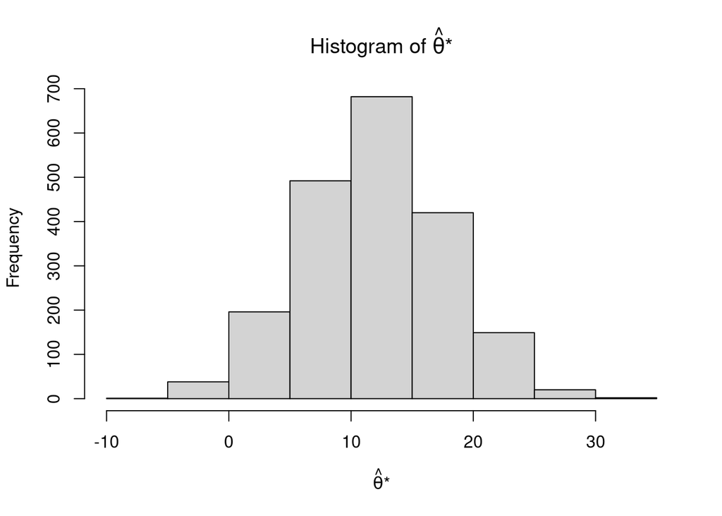

## (c) Confidence Intervals

```r
ci <- c(quantile(suff1_theta_star,.025),quantile(suff1_theta_star,.975))
```